# Explore And Summarize Data: Red Wine Quality

for **AIRBUS** Data Analyst Nanodegree Program

Pankaj NATH

09 March, 2020 Issue: 2.0

# 1 Table of Contents

1. Dataset Introdution
2. Univariate Plots
3. Univariate Analysis
4. Bivariate Plots
5. Bivariate Analysis
6. Multivariate Plots
7. Multivariate Analysis
8. Final Plots and Sumary
9. Reflection

# 2 Dataset Introduction

The dataset opted for this project to explore and summarize is **“Red Wine Quality”** dataset of the Portuguese **“Vinho Verde”** wine. This can be downloaded by clicking [here](https://s3.amazonaws.com/udacity-hosted-downloads/ud651/wineQualityReds.csv). The dataset has 1599 observations. But due to privacy and logistic issues, only physicochemical (inputs) and sensory (the output) variables are available (e.g. there is no data about grape types, wine brand, wine selling price, etc.)

Based on physicochemical tests, the attributes are listed below:

1. **fixed acidity** (tartaric acid - g / dm^3) : most acids involved with wine or fixed or nonvolatile (do not evaporate readily).
2. **volatile acidity** (acetic acid - g / dm^3) : the amount of acetic acid in wine, which at too high of levels can lead to an unpleasant, vinegar taste.
3. **citric acid** (g / dm^3) : found in small quantities, citric acid can add ‘freshness’ and flavor to wines.
4. **residual sugar** (g / dm^3) : the amount of sugar remaining after fermentation stops, it’s rare to find wines with less than 1 gram/liter and wines with greater than 45 grams/liter are considered sweet.
5. **chlorides** (sodium chloride - g / dm^3) : the amount of salt in the wine.
6. **free sulfur dioxide** (mg / dm^3) : the free form of SO2 exists in equilibrium between molecular SO2 (as a dissolved gas) and bisulfite ion; it prevents microbial growth and the oxidation of wine.
7. **total sulfur dioxide** (mg / dm^3) : amount of free and bound forms of S02; in low concentrations, SO2 is mostly undetectable in wine, but at free SO2 concentrations over 50 ppm, SO2 becomes evident in the nose and taste of wine.
8. **density** (g / cm^3) : the density of water is close to that of water depending on the percent alcohol and sugar content.
9. **pH** : describes how acidic or basic a wine is on a scale from 0 (very acidic) to 14 (very basic); most wines are between 3-4 on the pH scale.
10. **sulphates** (potassium sulphate - g / dm3) : a wine additive which can contribute to sulfur dioxide gas (S02) levels, wich acts as an antimicrobial and antioxidant.
11. **alcohol** (% by volume) : the percent alcohol content of the wine.

Based on sensory data, the output variable:

12. **quality** : score between 0 (very bad) and 10 (very excellent).

This would be interesting to see how each attribute contribute towards wine’s quality and also to see how these attributes are related with each other. Also we will investigate using available data if their are strong indications that wine quality depends on any particular chemical properties from above list.

Lets’ summarize our red wine dataset and view the variables and their mean, median, min, max and 1st & 3rd quartile values.

```
##        X          fixed.acidity   volatile.acidity  citric.acid
##  Min.   :   1.0   Min.   : 4.60   Min.   :0.1200   Min.   :0.000
##  1st Qu.: 400.5   1st Qu.: 7.10   1st Qu.:0.3900   1st Qu.:0.090
##  Median : 800.0   Median : 7.90   Median :0.5200   Median :0.260
##  Mean   : 800.0   Mean   : 8.32   Mean   :0.5278   Mean   :0.271
##  3rd Qu.:1199.5   3rd Qu.: 9.20   3rd Qu.:0.6400   3rd Qu.:0.420
##  Max.   :1599.0   Max.   :15.90   Max.   :1.5800   Max.   :1.000
##  residual.sugar     chlorides       free.sulfur.dioxide total.sulfur.dioxide
##  Min.   : 0.900   Min.   :0.01200   Min.   : 1.00       Min.   :  6.00
##  1st Qu.: 1.900   1st Qu.:0.07000   1st Qu.: 7.00       1st Qu.: 22.00
##  Median : 2.200   Median :0.07900   Median :14.00       Median : 38.00
##  Mean   : 2.539   Mean   :0.08747   Mean   :15.87       Mean   : 46.47
##  3rd Qu.: 2.600   3rd Qu.:0.09000   3rd Qu.:21.00       3rd Qu.: 62.00
##  Max.   :15.500   Max.   :0.61100   Max.   :72.00       Max.   :289.00
##     density             pH          sulphates         alcohol
##  Min.   :0.9901   Min.   :2.740   Min.   :0.3300   Min.   : 8.40
##  1st Qu.:0.9956   1st Qu.:3.210   1st Qu.:0.5500   1st Qu.: 9.50
##  Median :0.9968   Median :3.310   Median :0.6200   Median :10.20
##  Mean   :0.9967   Mean   :3.311   Mean   :0.6581   Mean   :10.42
##  3rd Qu.:0.9978   3rd Qu.:3.400   3rd Qu.:0.7300   3rd Qu.:11.10
##  Max.   :1.0037   Max.   :4.010   Max.   :2.0000   Max.   :14.90
##     quality
##  Min.   :3.000
##  1st Qu.:5.000
##  Median :6.000
##  Mean   :5.636
##  3rd Qu.:6.000
##  Max.   :8.000
```

# 3 Univariate Plots Section

## 3.1 Wine Quality

Let’s start by exploring wine quality which ranges in [3, 8] for our dataset. This is definately an ordered categorical variable.

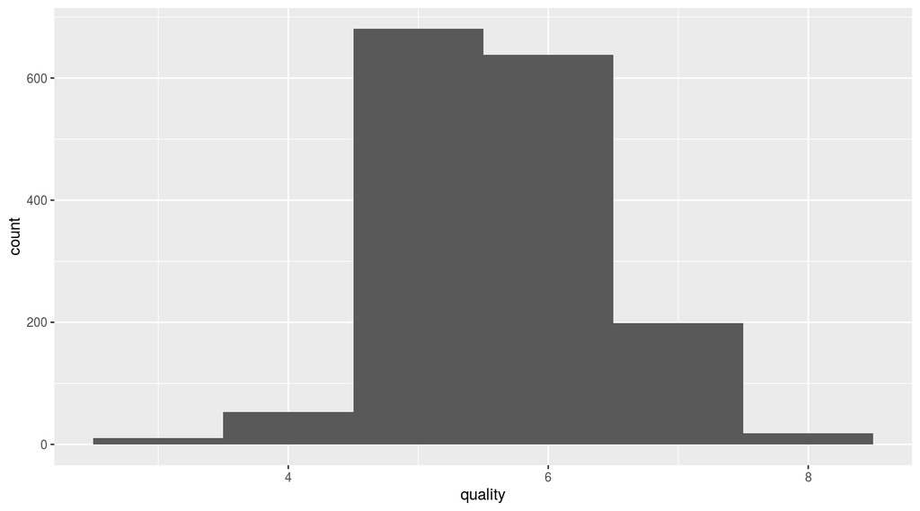

```
##    Min. 1st Qu.  Median    Mean 3rd Qu.    Max.
##   3.000   5.000   6.000   5.636   6.000   8.000
```

```
##
##   3   4   5   6   7   8
##  10  53 681 638 199  18
```

There are only 10 observations with quality rating of 3 and 18 observations with quality rating of 8. Majority of observations are rated at 5 or 6. Distribution of quality is normal but on a very narrow range.

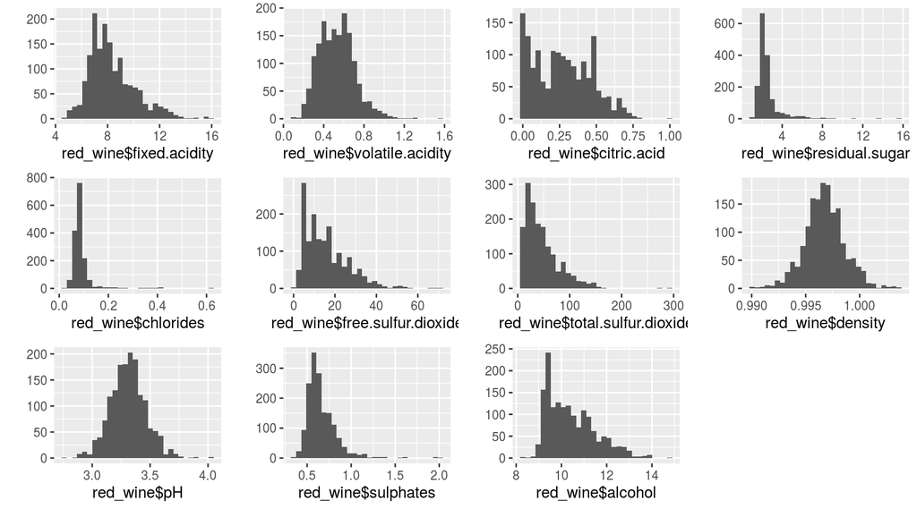

It would be interesting to investigate distribution of Citric Acid, Resedual Sugar, Chlorides, Free Sulphur Dioxide, Total Sulphur Dioxide, Sulphate and Alcohol. All of these variables do not seem to be normally distributed.

## 3.2 Alcohol

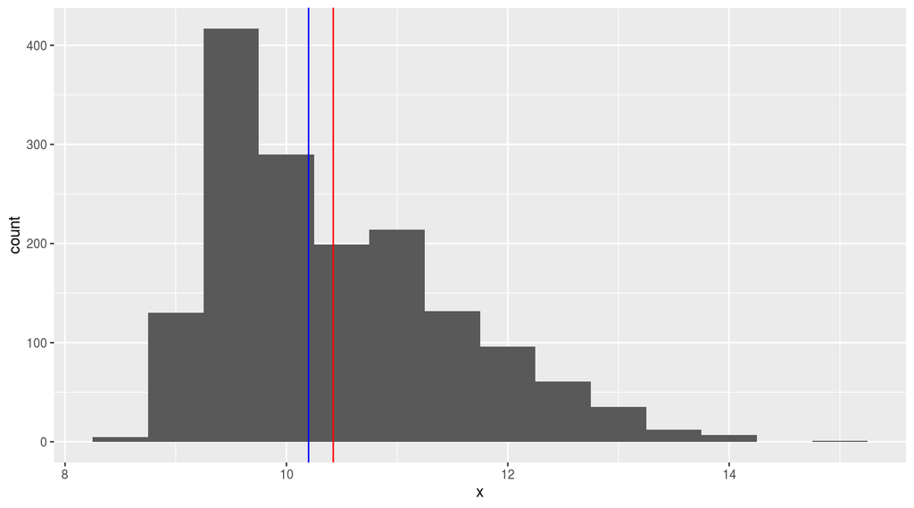

```
##    Min. 1st Qu.  Median    Mean 3rd Qu.    Max.
##    8.40    9.50   10.20   10.42   11.10   14.90
```

Clearly the alcohol quantity in our red wine dataset is skwed with median of 10.2 being closer to minimum (8.4) compared to maximum (14.9).

## 3.3 Sulphates

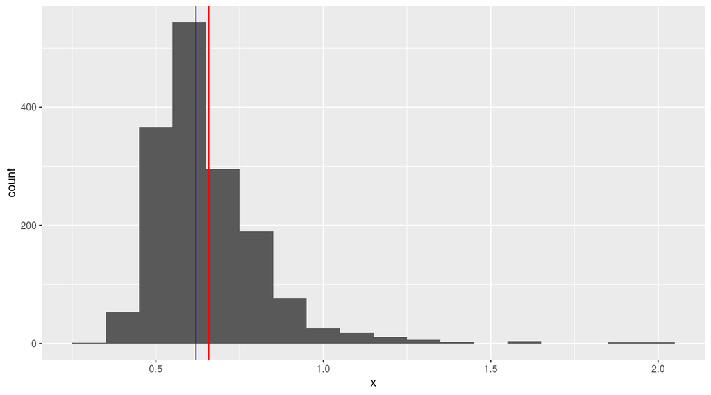

```
##    Min. 1st Qu.  Median    Mean 3rd Qu.    Max.
##  0.3300  0.5500  0.6200  0.6581  0.7300  2.0000
```

Distribution of sulphates is also skewed and mean & median is very close to minimum with higher gap between third quartile and maximum. It would be interesting to investigate the quality of these outliers on the higher side.

## 3.4 Chlorides

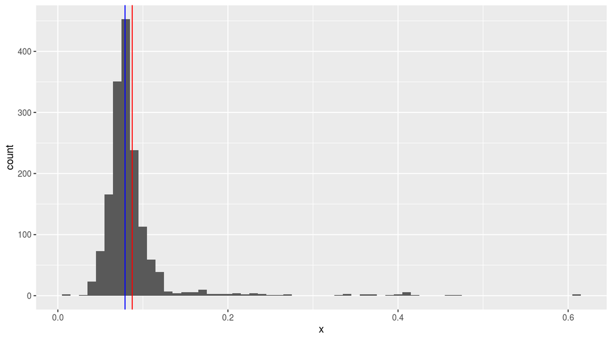

```
##    Min. 1st Qu.  Median    Mean 3rd Qu.    Max.
## 0.01200 0.07000 0.07900 0.08747 0.09000 0.61100
```

Distribution of chlorides is skewed similar to sulphates, with outliers on the higher side.

## 3.5 Residual Sugar

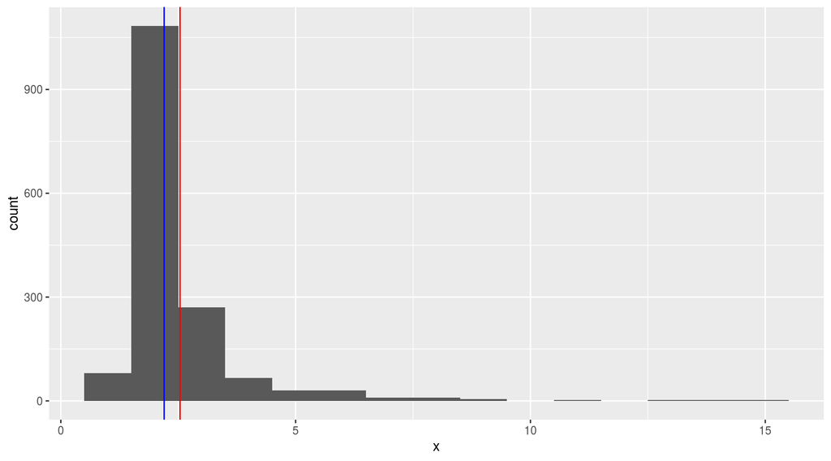

```
##    Min. 1st Qu.  Median    Mean 3rd Qu.    Max.
##   0.900   1.900   2.200   2.539   2.600  15.500
```

Distribution of residual sugar is skewed similar to sulphates and chlorides with outliers on the higher end.

## 3.6 Citric Acid

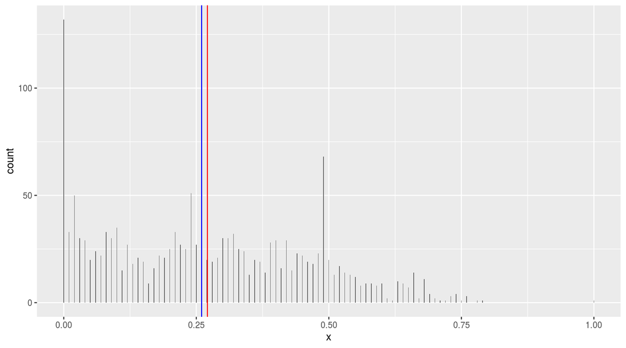

```
##    Min. 1st Qu.  Median    Mean 3rd Qu.    Max.
##   0.000   0.090   0.260   0.271   0.420   1.000
```

With a smaller bin size of 0.001 we can observe very interesting fact that the citric acid quantity in our dataset is clustered. It would be interesting to see if quality is also clustered with it or not?

## 3.7 Total Sulphur Dioxide

This is the sum of free sulphur dioxide and bound sulphur dioxide. Using total SO2 along with free SO2 may have correlation between them. To break any bias between them, a new variable bound sulphur dioxide will be created and total SO2 will be dropped from the dataset.

## 3.8 Free & Bound Sulphur Dioxide

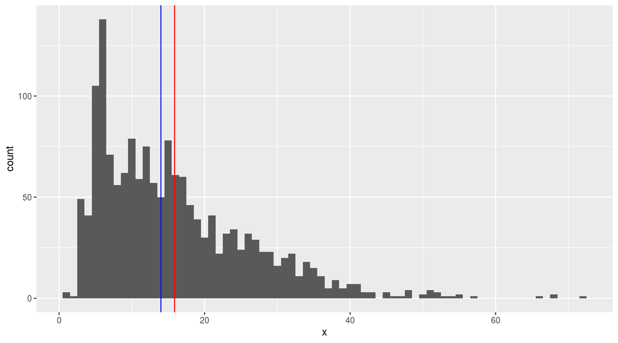

```
##    Min. 1st Qu.  Median    Mean 3rd Qu.    Max.
##    1.00    7.00   14.00   15.87   21.00   72.00
```

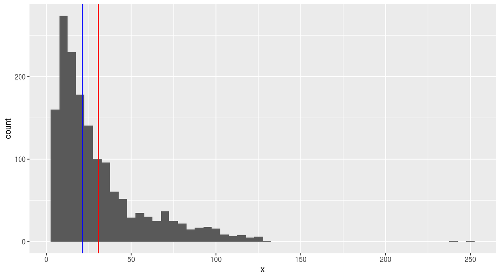

```
##    Min. 1st Qu.  Median    Mean 3rd Qu.    Max.
##    3.00   12.00   21.00   30.59   39.00  251.50
```

Both Free and Bound Sulphur dioxide is also has a skewed long tailed distribution with outliers like previous other variables.

# 4 Univariate Analysis

## 4.1 What is the structure of your dataset?

> The red wine dataset has 12 parameters including quality with a total of 1599 observations or datapoints. Quality is an ordered categorical parameter whereas rest all were of type float. This dataset was a tidy one hence no values were missing and no cleaning was required except dropping the X parameter which was nothing but id for each observation point in dataset and not needed for my analysis.

## 4.2 What is/are the main feature(s) of interest in your dataset?

> Main feature of this dataset is the quality which has defined range of 0 (very poor) to 10 (very excellent) but our dataset has values in the range of [3, 8] only. I would like to investigate how each of the other features affect quality.

## 4.3 What other features in the dataset do you think will help support your investigation into your feature(s) of interest?

> Most of the features are skewed in distribution but quality has most observations at rating 5 or 6. With just Univariate Plots, it is difficult to predict or say anything of sure. I would like to go ahead and continue with Bivariate and Multivariate analysis.

## 4.4 Did you create any new variables from existing variables in the dataset?

> Total Sulfur Dioxide was sum of Free and Bound Sulfur Dioxide in the wine. Our dataset had both total and Free SO2 values present. Since these two features are directly related to each other and are biased, I decided to create and new variable Bound Sulfur Dioxide using these two and then drop Total sulfur Dioxide from the dataset. This gave me two variables which were no more directly related.

## 4.5 Of the features you investigated, were there any unusual distributions?

> One interesting distribution of Citric Acid was observed to be clustered. There were many local peaks present.

## 4.6 Did you perform any operations on the data to tidy, adjust, or change the form of the data? If so, why did you do this?

> As mentioned in previous questions, with justifications, X and Total Sulfur Dioxide variables were dropped and a new variable Bound Sulfur Dioxide was created.

# 5 Bivariate Plots Section

Let us begin with investigating correlations between all the variables using a correlation matrix. Based on the value of Pearson’s coefficient of correleation we can say any value less than +/- 0.4 shows weak or no correlation. Any +/- value between 0.5 and 0.7 shows moderate correlation. And any value higher to +/- 0.7 shows strong correleation.

```
##                      fixed.acidity volatile.acidity citric.acid residual.sugar
## fixed.acidity                 1.00            -0.26        0.67           0.11
## volatile.acidity             -0.26             1.00       -0.55           0.00
## citric.acid                   0.67            -0.55        1.00           0.14
## residual.sugar                0.11             0.00        0.14           1.00
## chlorides                     0.09             0.06        0.20           0.06
## free.sulfur.dioxide          -0.15            -0.01       -0.06           0.19
## density                       0.67             0.02        0.36           0.36
## pH                           -0.68             0.23       -0.54          -0.09
## sulphates                     0.18            -0.26        0.31           0.01
## alcohol                      -0.06            -0.20        0.11           0.04
## quality                       0.12            -0.39        0.23           0.01
## bound.sulfur.dioxide         -0.08             0.10        0.07           0.17
##                      chlorides free.sulfur.dioxide density    pH sulphates
## fixed.acidity             0.09               -0.15    0.67 -0.68      0.18
## volatile.acidity          0.06               -0.01    0.02  0.23     -0.26
## citric.acid               0.20               -0.06    0.36 -0.54      0.31
## residual.sugar            0.06                0.19    0.36 -0.09      0.01
## chlorides                 1.00                0.01    0.20 -0.27      0.37
## free.sulfur.dioxide       0.01                1.00   -0.02  0.07      0.05
## density                   0.20               -0.02    1.00 -0.34      0.15
## pH                       -0.27                0.07   -0.34  1.00     -0.20
## sulphates                 0.37                0.05    0.15 -0.20      1.00
## alcohol                  -0.22               -0.07   -0.50  0.21      0.09
## quality                  -0.13               -0.05   -0.17 -0.06      0.25
## bound.sulfur.dioxide      0.06                0.43    0.10 -0.11      0.03
##                      alcohol quality bound.sulfur.dioxide
## fixed.acidity          -0.06    0.12                -0.08
## volatile.acidity       -0.20   -0.39                 0.10
## citric.acid             0.11    0.23                 0.07
## residual.sugar          0.04    0.01                 0.17
## chlorides              -0.22   -0.13                 0.06
## free.sulfur.dioxide    -0.07   -0.05                 0.43
## density                -0.50   -0.17                 0.10
## pH                      0.21   -0.06                -0.11
## sulphates               0.09    0.25                 0.03
## alcohol                 1.00    0.48                -0.22
## quality                 0.48    1.00                -0.21
## bound.sulfur.dioxide   -0.22   -0.21                 1.00
```

We didnot observed any stong correlation between any of the variables but yes some moderate correlation is observed between following pairs of variables:

1. fixed.acidity & citric.acid : 0.67
2. fixed.acidity & density : 0.67
3. fixed.acidity & pH : -0.68
4. volatile.acidity & citric.acid : -0.55
5. citric.acid & pH : -0.54
6. density & alcohol : -0.50

Let’s also visualize the heatmap for our correlation matrix below. The code used for this visualization is taken from [here](http://www.sthda.com/english/wiki/ggplot2-quick-correlation-matrix-heatmap-r-software-and-data-visualization).

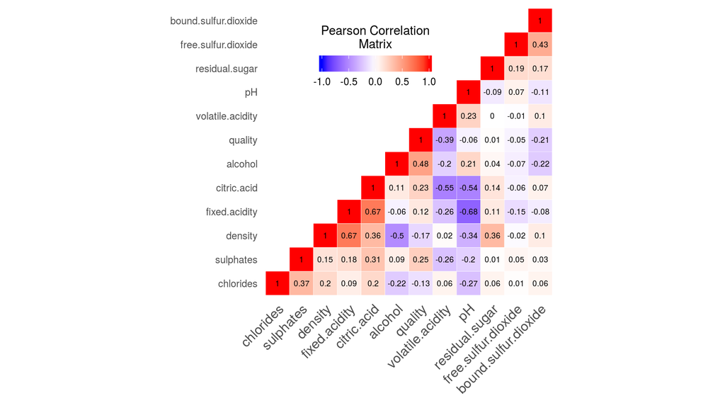

## 5.1 Plot of fixed.acidity & citric.acid

Both these variables are showing a positive correlation of **0.67**. Lets view them in a scatter plot with trendline.

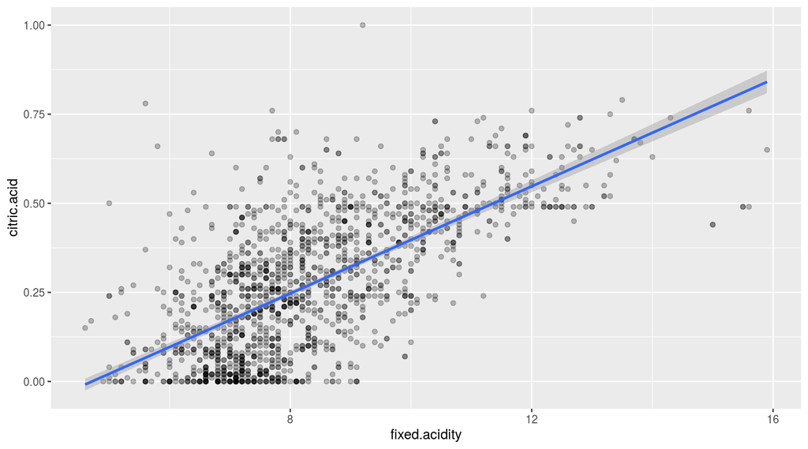

## 5.2 Plot of fixed.acidity & pH

Both these variables are showing a negative correlation of **-0.68**. Lets view them in a scatter plot with trendline.

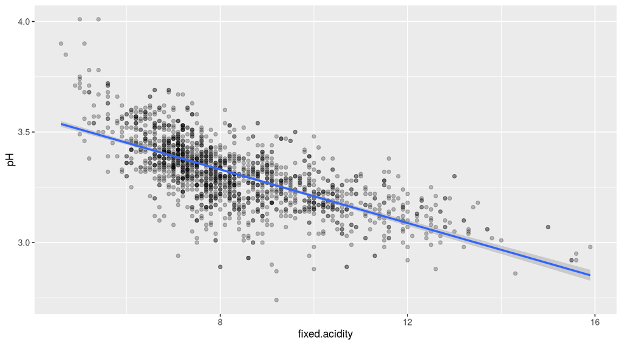

## 5.3 Plot of quality vs sulphates

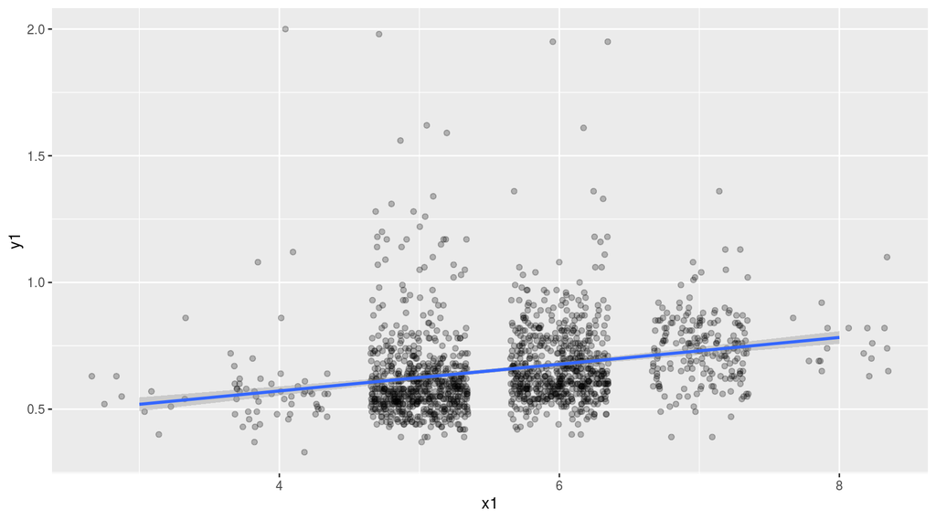

As expected, we cannot comment on quality based on sulphates quantity in red wine.

## 5.4 Plot of quality vs chlorides

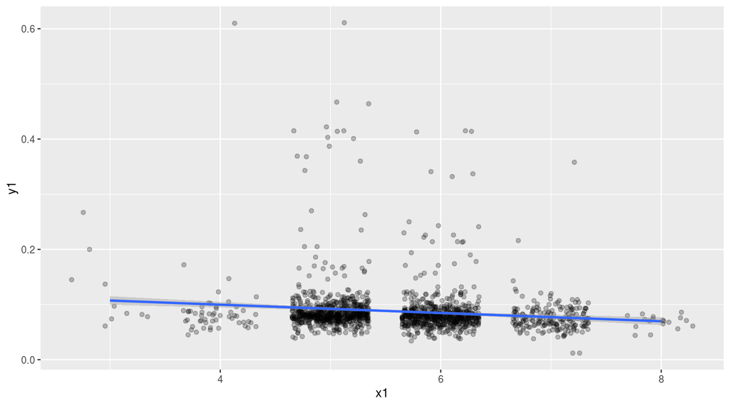

From the plot the weaker correlation between quality and chlorides is evident. Lower chlorides in red wine doesnot gives higher quality of red wine.

## 5.5 Plot of quality vs alcohol

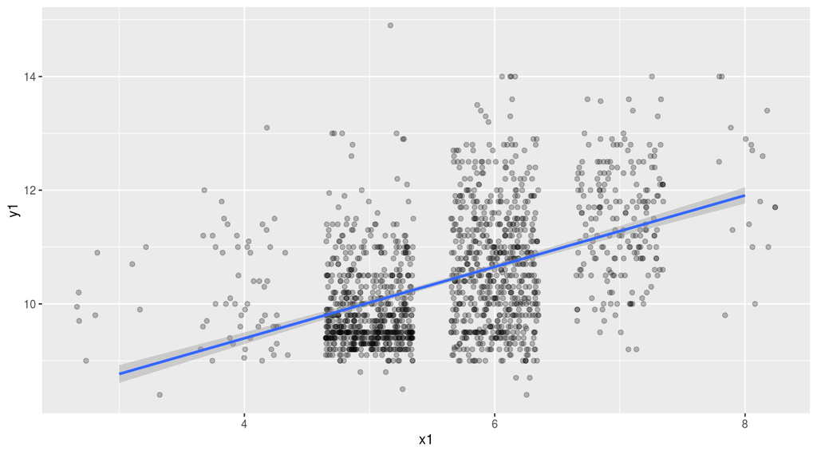

The correlation coefficient between alcohol quantity and quality of red wine was **0.48**. It wasn’t much but the trendline shows that the most high quality red wines have higher alcohol quantity in them. A boxplot between quality and alcohol variables may provide some more insights.

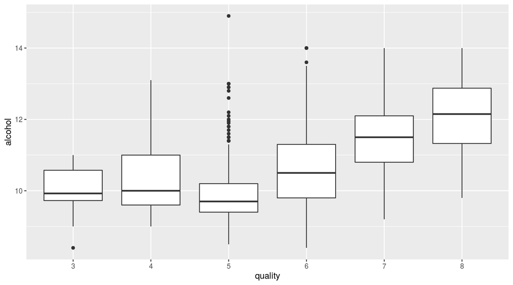

# 6 Bivariate Analysis

## 6.1 Talk about some of the relationships you observed in this part of the investigation. How did the feature(s) of interest vary with other features in the dataset?

> The feature of interest for our examination is quality. But we did not find any strong correlation between any of the other features with our feature of interest (quality). Quality had near to moderate positive correlation of **0.48** with alcohol and highest negative correlation of **-0.39** with volatile acidity. We validated the weaker trend that with sulphates and chlorides.

## 6.2 Did you observe any interesting relationships between the other features (not the main feature(s) of interest)?

> The very first action was to calculate the correlation coefficients between all features involved. Overall we did not find any strong correlations (> 0.7) between these features but some moderate correlations (> 0.5 & < 0.7) were found. Among them, two pairs of features had the highest positive correlation of **0.67** between fixed.acidity & citric.acid and fixed.acidity & density. The highest negative correlation on **-0.68** was found for fixed.acidity & pH.

## 6.3 What was the strongest relationship you found?

> The only strongest positive trend we saw for quality was with alcohol where most of the higher rated wines had higher alcohol content. With the help of boxplot we found that initially the alcohol content drops from a poor quality wine to moderate quality (rating 5). Afterwards the alcohol content increases with quality. But this correlation doesnot prove this causation since many of the higher alcohol content wines were rated moderately.

# 7 Multivariate Plots Section

First multivariate plot will include Citric Acid, Alcohol and Quality.

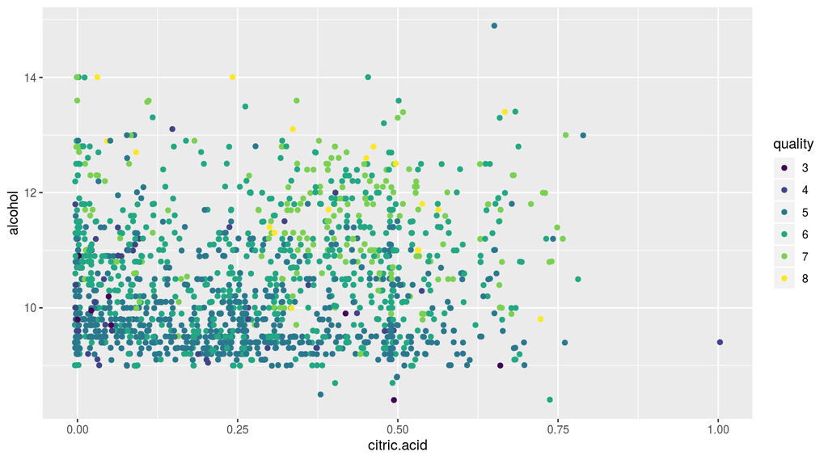

The features selected for first multivariate plot do not convey any strong message. But a slight hint is visible that moderate quality red wines have alcohol content and citric acid values on the lower end, whereas quality improves with increase in these two featrue values.

Second multivariate plot will include Alcohol, Density and Quality.

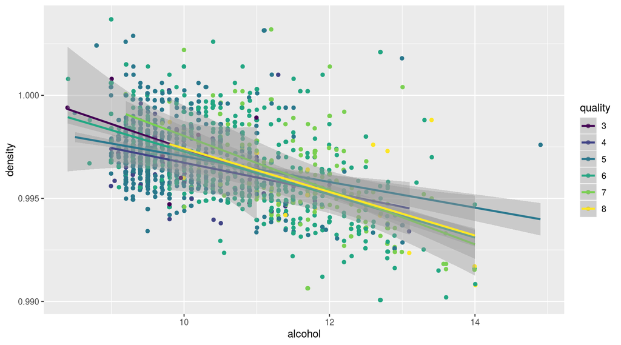

Second multivariate plot shows that more better quality red wines have alcohol content above 10 and density lower to 0.9975.

# 8 Multivariate Analysis

## 8.1 Talk about some of the relationships you observed in this part of the investigation. Were there features that strengthened each other in terms of looking at your feature(s) of interest?

> Higher alcohol and citric acid content combined with lower density are essential but not sufficient features for better quality of red wine.

## 8.2 Were there any interesting or surprising interactions between features?

> The relationship between alcohol and density: increase in alcohol quantity and decrease in density, is interesting for me to investigate if this can really be possible in terms of chemistry?

# 9 Final Plots and Summary

## 9.1 Plot One

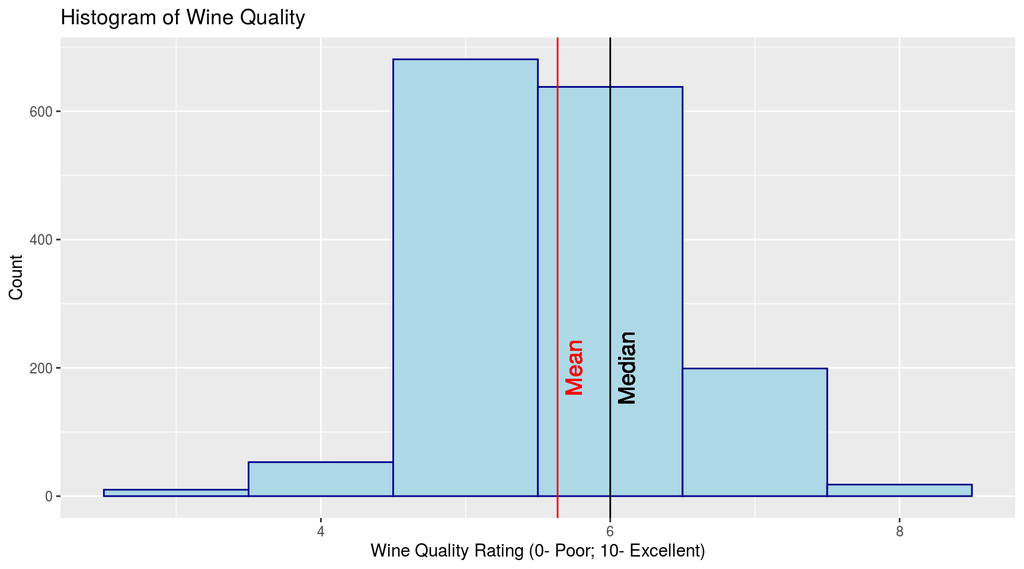

### 9.1.1 Description One

The red wine dataset had 12 features including the feature of our interest (quality). The first plot is a histogram showing the distribution of quality in our red wine dataset. It was evident from this plot that most of our wine samples were from rating 5 or 6. This dataset did not have any outliers with rating 0 or 10 with a mean of **5.636** and median of **6**. This dataset had very narrow distribution range of quality as [**3, 8**].

## 9.2 Plot Two

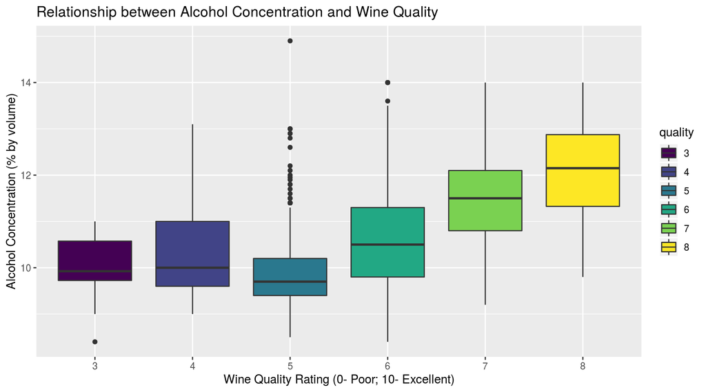

## 9.3 Plot Three

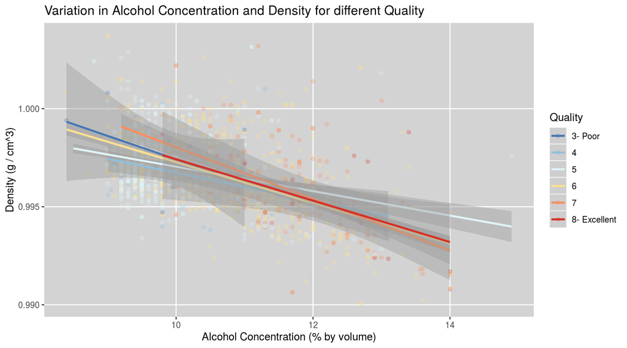

### 9.3.1 Description Three

The third plot integrates density feature along with alcohol concentration to see the behaviour with respect to quality of wine. It is then visible that highly rated red wines have lower density and higher alcohol concentration by volume.

# 10 Reflection

In this project I explored and examined a tidy red wine dataset which was composed of 1599 observations of 12 variables. These variables included physicochemical properties of red wine and median of quality from three human expert testers.

I started my investigations firstly by reading the information about the dataset and its variables. Then I started with analyzing the distributions of each of these variables in univariate plots and analysis. Before starting bivariate analysis, I did the heatmap of Pearson’s correlation coefficients. This was helpful in picking up pairs of variables to bivariate plots and analysis. Then I concluded my multivariate plots and analysis.

It was very interesting to see the distribution of citric acid which had many local maximums and minimums. I was wondering if citric acid is really an important variable or not? Though it had only a weak correlation with quality variable, I wonder having data domain knowledge would have been very helpful.

The first challenge I faced while initiating this investigation was to identfy and install all the packages that I would need. My computer was always throughing error. Then I came across the [R Studio Cloud](https://rstudio.cloud), it was very smooth in working and all my work was in cloud, accessible from anywhere, anytime. I loved working on this platform.

While working with the dataset, I identified that quality was a categorical variable. So I changed it to an ordered variable. In some plots I faced issues since it became discrete variable. I also then thought about why can’t this quality variable be a continuous? I found the answer, it was a median from three wine testers who may have rated only using integers between 0 to 10.

A lot could have been possible to investigated if the outcome of each wine tester was provided separately. Then it could have been the analyst’s choice to take a continous mean or median to proceed with.

Also this dataset had many observations from rating 5 or 6. It was missing some outliers such a very poor (rating 0) or very excellent (rating 10). Without these outliers we may have missed the actual relationship these best or worst red wine would have with all other 11 variables.

I did not created any model with this dataset. With above mentioned deficiency of this dataset, I wonder if the model will work good or not. May be for future this dataset can be imroved then creating a model could be a future endeavour.